# Phylogenetic Analysis of Brazilian mtDNA Sequences

Gepoliano Chaves

May 23rd, 2024

# 1. Introduction

## 1.1. Mitochondrial genome and matrilinear information

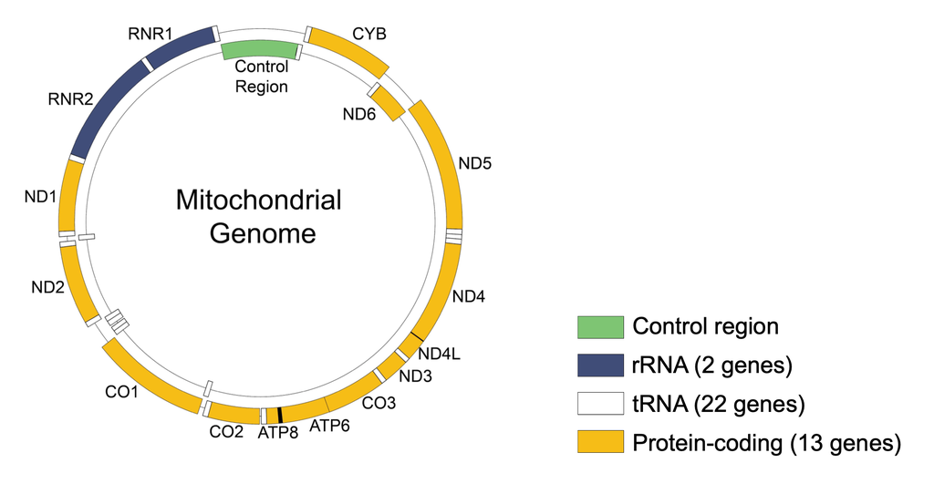

## 1.2. Mitochondrial haplogroups

- Genetic variants (mutations) in mitochondrial DNA can be organized in haplogroups.
- Each matrilineal ancestry has characteristic haplogroups.
- This figure from Mitchell et al., 2014 shows the phylogenetic tree of mitochondrial haplogroups in a large population of the USA.

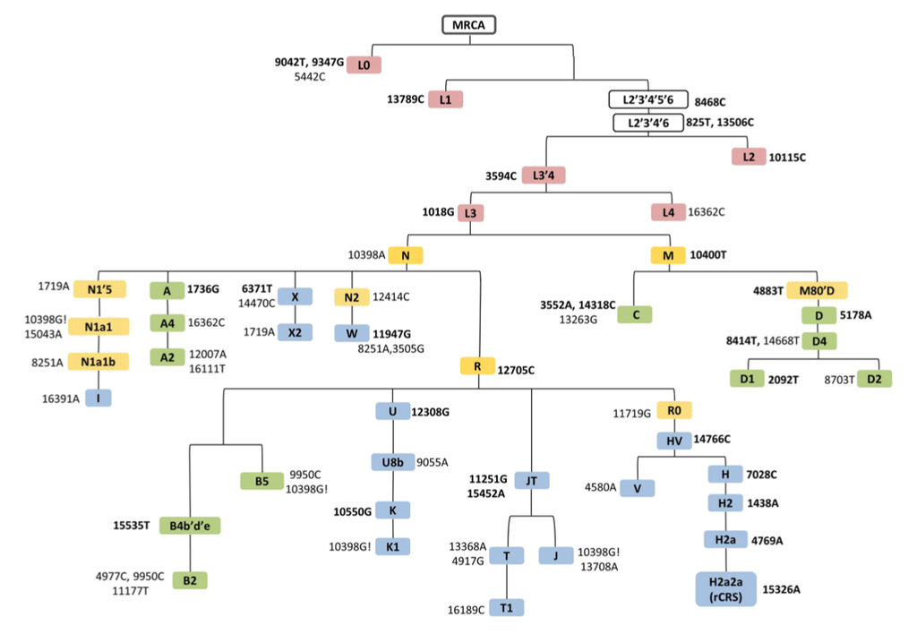

Classification tree of mitochondrial haplogroups. Figure from Sabrina L. Mitchell (2014).

# 2. Computational Imputation and Databases

- A review on genotype imputation was writen by Yun Li and Abecasis (2009). They even mention using the HapMap project as panels for genotype inference. They do not mention an imputation workflow or protocol for genetic variants of Brazilians. An imputation workflow was provided by Kalle Pärn (2018).
- I was able to find an R function for imputation in https://search.r-project.org/CRAN/refmans/dotgen/html/imp.html
- The function above is in package https://cran.r-project.org/web/packages/dotgen/index.html

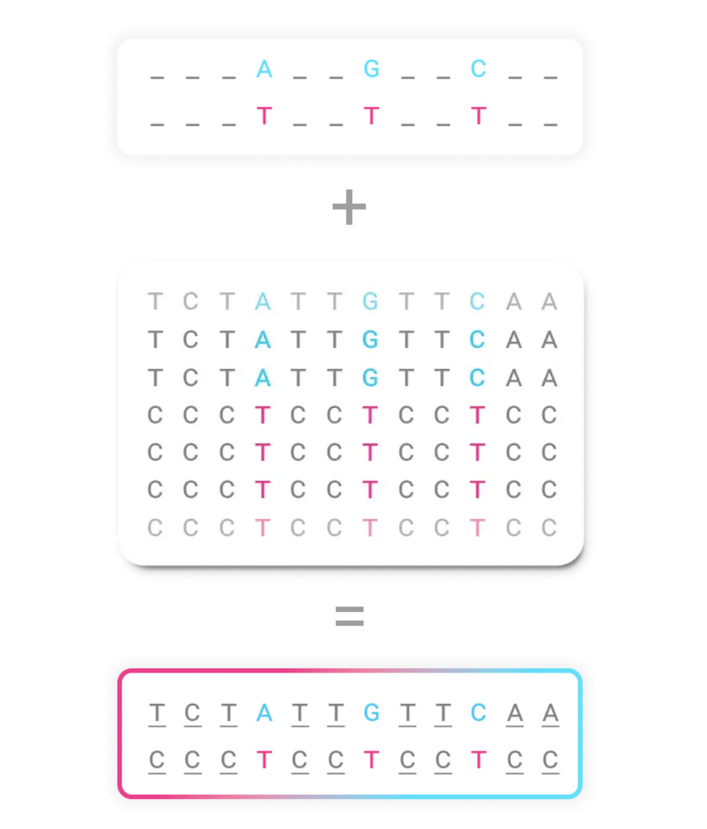

Reference panels can be used to create populational references. With milions or billions of sequences deposited in a database, a genetic model can be created or imputed. Figure from tellmeGen (n.d.).

# 3. Alignment

## Load multi-fasta mtDNA file

Load package msa: multiple sequence alignment

```r
library("msa")
```

Load multi-fasta mtDNA from Brazil.

```r
mt_brazilian <- readDNAStringSet(file="../../DNA do Brasil/matrilineal sequences/data/mt_brazilian.fasta")
```

Information about subsetting strings was gained from Chapter 4: Manipulating Sequences with Biostrings, found in Gatto (2023).

```r
seq_start_to_end <- subseq(mt_brazilian, start = 100, end = 200)
```

Print sequence

```r
print(seq_start_to_end)
```

```
## DNAStringSet object of length 17:
##      width seq                                              names
##  [1]   101 ATAAAAACCCAATCCACATCAAA...CAACTGCAACTCCAAAGCCACC AF243780
##  [2]   101 ATGAAAACCCAATCCACATCAAA...CAACTGCAACTCCAAAGCCACC AF243781
##  [3]   101 ATAAAAACCCAATCCACATCAAA...CAACTGCAACTCCAAAGCCACC AF243782
##  [4]   101 ATAAAAACCCAATCCACATCAAA...CAACTGCAACTCCAAAGCCACC AF243783
##  [5]   101 ATAAAAACCCAATCCACATCAAA...CAACTGCAACTCCAAAGCCACC AF243784
##  ...   ... ...
## [13]   101 ATAAAAACCCAATCCACATCAAA...CAACTGCAACTCCAAAGCCACC AF243792
## [14]   101 ATAAAAACCCAATCCACATCAAA...CAACTGCAACTCCAAAGCCACC AF243793
## [15]   101 ATAAAAACCCAATCCACATCAAA...CAACTGCAACTCCAAAGCCACC AF243794
## [16]   101 ATAAAAACCCAATCCACATCAAA...CAACTGCAACTCCAAAGCCACC AF243795
## [17]   101 ATAAAAACCCAATCCACATCAAA...CAACTGCAACTCCAAAGCCACC AF243796
```

Align sequences

```r
start_time <- Sys.time()
alignment_start_to_end <- msa(seq_start_to_end)
```

```
## use default substitution matrix
```

```r
end_time <- Sys.time()
end_time - start_time
```

```
## Time difference of 0.069911 secs
```

```r
alignment_start_to_end
```

```
## CLUSTAL 2.1
##
## Call:
##    msa(seq_start_to_end)
##
## MsaDNAMultipleAlignment with 17 rows and 102 columns
##      aln                                                   names
##  [1] ATAAAAACCCAATCCACATCAAAAC...ATCAACTGCAACTCCAAAGCCACC- AF243780
##  [2] ATGAAAACCCAATCCACATCAAAAC...ATCAACTGCAACTCCAAAGCCACC- AF243781
##  [3] ATAAAAACCCAATCCACATCAAAAC...ATCAACTGCAACTCCAAAGCCACC- AF243789
##  [4] ATAAAAACCCAATCCACATCAAAAC...ATCAACTGCAACTCCAAAGCCACC- AF243786
##  [5] ATAAAAACCCAATCCACATCAAAAC...ATCAACTGCAACTCCAAAGCCACC- AF243795
##  [6] ATAAAAACCCAATCCACATCAAAAC...ATCAACTGCAACTCCAAAGCCACC- AF243796
##  [7] ATAAAAACCCAATCCACATCAAAAC...ATCAACTGCAACTCCAAAGCCACC- AF243785
##  [8] ATAAAAACCCAATCCACATCAAAAC...ATCAACTGCAACTCCAAAGCCACC- AF243787
##  [9] ATAAAAACCCAATCCACATCAAAAC...ATCAACTGCAACTCCAAAGCCACC- AF243794
## [10] ATAAAAACCCAATCCACATCAAAAC...ATCAACTGCAACTCCAAAGCCACC- AF243783
## [11] ATAAAAACCCAATCCACATCAAAAC...ATCAACTGCAACTCCAAAGCCACC- AF243784
## [12] ATAAAAACCCAATCCACATCAAAAC...ATCAACTGCAACTCCAAAGCCACC- AF243791
## [13] ATAAAAACCCAATCCACATCAAAAC...ATCAACTGCAACTC-AAAGCCACCC AF243788
## [14] ATAAAAACCCAATCCACATCAAAAC...ATCAACTGCAACTCCAAAGCCACC- AF243793
## [15] ATAAAAACCCAATCCACATCAAAAC...ATCAACTGCAACTCCAAAGCCACC- AF243782
## [16] ATAAAAACCCAATCCACATCAAAAC...ATCAACTGCAACTCCAAAGCCACC- AF243792
## [17] ATAAAAACCCAATCCACATCAAAAC...ATCAACTGCAATTCCAAAGCCACC- AF243790
##  Con ATAAAAACCCAATCCACATCAAAAC...ATCAACTGCAACTCCAAAGCCACC- Consensus
```

# 3. Alignment Visualization

### Load library

```r
library(ggmsa)
```

### Visualization with sample names

[output not shown]

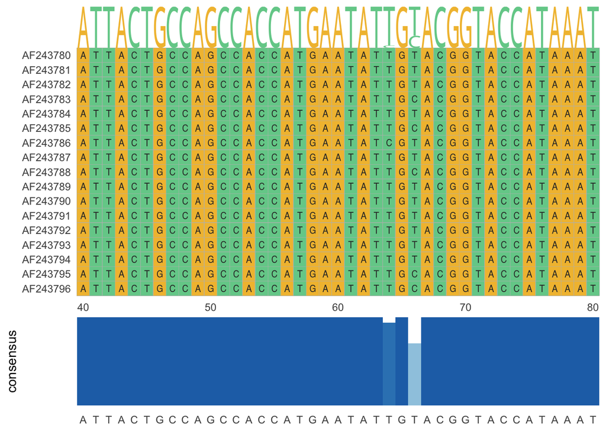

```r
ggmsa(mt_brazilian,
      start = 40, end = 80,
      char_width = 0.5,
      seq_name = T) + geom_seqlogo() + geom_msaBar()
```

### Visualization without sample names

- Plot without sequence names

[output not shown]

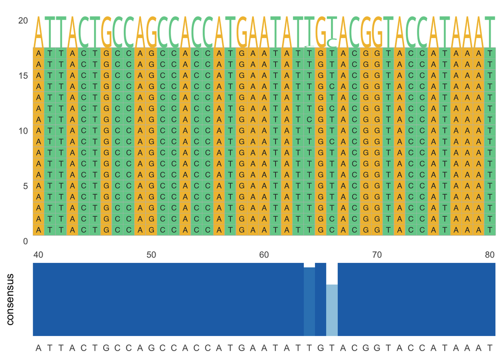

```r
ggmsa(mt_brazilian,
      start = 40, end = 80,
      char_width = 0.5,
      seq_name = F) + geom_seqlogo() + geom_msaBar()
```

# 5. Visualize Haplogroup Classification with Haplogrep 3

Visualization is available https://haplogrep.readthedocs.io/en/latest/annotations/#clusters-and-population-frequencies

# 6. Distance Matrix and Phylogenetic Tree of Partial Sequence

This is necessary so function dist.ml can take the DNA.bin object and process the Distance Matrix. Function dist.ml() is from package phangorn

```r
library("phangorn")
dm_extremo_sul_msa_partial <- dist.ml(as.DNAbin(alignment_start_to_end))
```

## Plot distance matrix

Function table.paint() is from package adegenet. Load library adegenet:

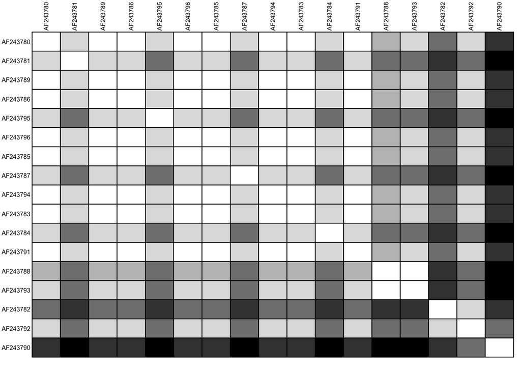

```r
library("adegenet")
dm_extremo_sul_msa_partial_df <- as.data.frame(as.matrix(dm_extremo_sul_msa_partial))
table.paint(dm_extremo_sul_msa_partial_df, cleg=0, clabel.row=.5, clabel.col=.5)
```

## Construct Phylogenetic Trees

Phylogenetic tree UPGMA method

```r
treeUPGMA_extremo_sul_partial <- upgma(dm_extremo_sul_msa_partial_df)
```

## Plot Phylogenetic Trees Extremo Sul

Plot UPGMA Extremo Sul

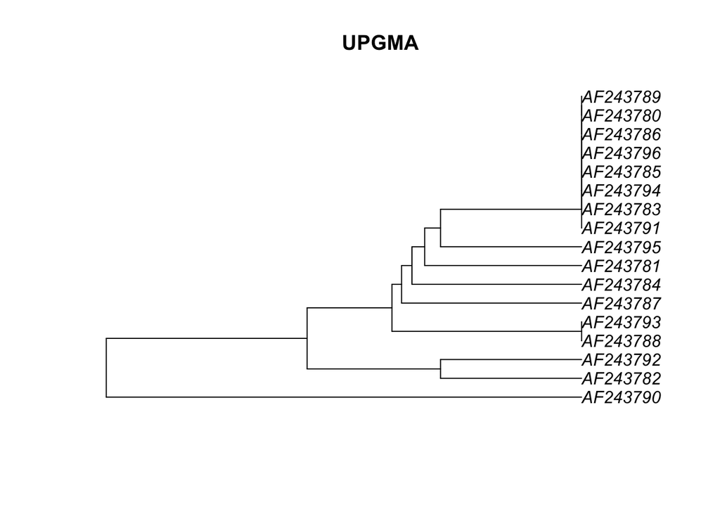

```r
plot(treeUPGMA_extremo_sul_partial, main="UPGMA", col="red")
```

## 7. References

Bolze, Alexandre. 2014. *Analysis of Mitochondrial DNA Variants in 200,000 Individuals*. https://cdn.sanity.io/files/g5irbagy/production/960b88f3fd681a6207e9d18b9973e99fa6df9e1f.pdf.

Gatto, Laurent. 2023. *Chapter 4 Manipulating Sequences with Biostrings*. https://uclouvain-cbio.github.io/WSBIM1322/sec-biostrings.html.

Kalle Pärn, Javier Nunez Fontarnau, Marita A. Isokallio. 2018. *Genotype Imputation Workflow V3.0 v.1*. https://www.protocols.io/view/genotype-imputation-workflow-v3-0-e6nvw78dlmkj/v1?step=3.

Sabrina L. Mitchell, Kristin Brown‐Gentry, Robert Goodloe. 2014. *Characterization of Mitochondrial Haplogroups in a Large Population‐based Sample from the United States*. https://www.ncbi.nlm.nih.gov/pmc/articles/PMC4113317/.

tellmeGen. n.d. *Genética Preditiva*. Accessed May 2, 2024. https://www.tellmegen.com/pt/genetica-preditiva.

Yun Li, Serena Sanna, Cristen Willer, and Gonçalo Abecasis. 2009. *Genotype Imputation*. https://pubmed.ncbi.nlm.nih.gov/19715440/.

Zhou, Lang. 2022. *Ggmsa:a Visual Exploration Tool for Multiple Sequence Alignment and Associated Data*. http://yulab-smu.top/ggmsa/index.html.